# Practical Machine Learing Assignment

## Summary

This assignment use Weight Liftining Exercise data set. The data were collected from experiment conducted by 6 testers. They had to perform ten times of biceps curl with dumbbell and try 5 variations. In this experiment, decision tree, generalized boosted model, and random forest are used for the model.

### Working with data

```r
# first, we load the data into variables
train <- read.csv("data/pml-training.csv", na.strings = c("", NA, "#DIV/0!"))
test <- read.csv("data/pml-testing.csv", na.strings = c("", NA, "#DIV/0!"))
train$classe <- as.factor(train$classe)

# activate/load the caret library
library(caret)
# we ignore the columns that contains NA
train <- train[,colSums(is.na(train)) == 0]
train <- subset(train, select = -c(1:7))
test <- test[,colSums(is.na(test)) == 0]
test <- test[,-c(1:7)]
```

Now we take some training data and allocate them for validation later.

```r
set.seed(42)
inTrain <- createDataPartition(train$classe, p = 0.75, list = F)
trainsub <- train[inTrain,]
testsub <- train[-inTrain,]
```

Next, we check their correlation

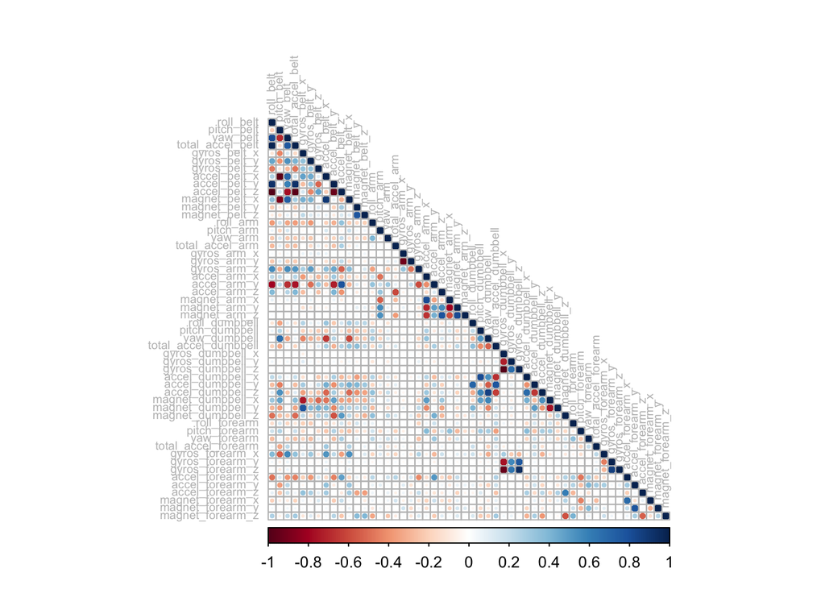

```r
# activate/load the ggplot library
library(ggplot2)

# activate/load the corrplot library
library(corrplot)
corrplot(cor(trainsub[,-c(53)]),method = "circle", type = "lower",tl.cex = 0.6, tl.col = "grey")
```

### Predicion with Tree

First, we try decision tree. Some variables are used for classification.

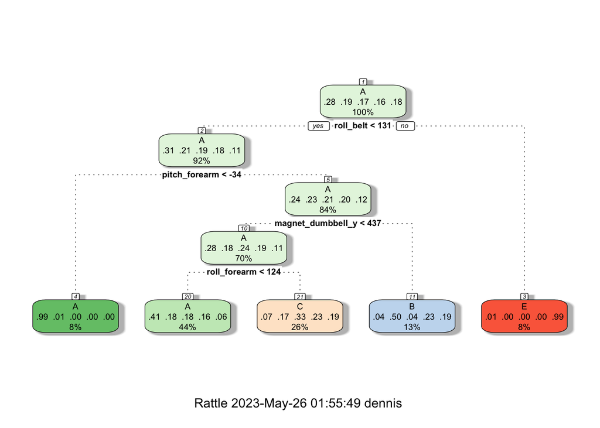

```r
set.seed(42)
tree.model <- train(classe ~ ., data = trainsub, method = "rpart")

# plot
library(rattle)
fancyRpartPlot(tree.model$finalModel)
```

```r
# perdiction and its accuracy
pred <- predict(tree.model, testsub)
confusionMatrix(pred, as.factor(testsub$classe))$overall["Accuracy"]
```

```
##  Accuracy
## 0.4957178
```

### Generalized Boosted Model

```r
set.seed(42)
library(gbm)
gbm.model <- gbm(formula = classe ~ . , distribution = "multinomial", data = trainsub, verbose = F,n.trees = 100)
gbm.pred <- predict(gbm.model, testsub, type = "response", n.trees = 100)
pred_c <- apply(gbm.pred, 1, which.max)
pred_c <- as.factor(pred_c)
levels(pred_c) <- c("A","B","C","D","E")
confusionMatrix(pred_c, testsub$classe)$overall["Accuracy"]
```

```
##  Accuracy
## 0.8144372
```

### Random Forest Technique

```r
set.seed(42)
library(randomForest)
rf.model <- randomForest(classe ~ ., data = trainsub, method = "class",
                         ntree = 50, mtry = 17,do.trace = F, proximity = T, importance = T)
pred <- predict(rf.model, testsub, type = "class")
confusionMatrix(pred, as.factor(testsub$classe))$overall[1]
```

```
##  Accuracy
## 0.9944943
```

Now, we may check on error value rate of classes an out-of-bag. out-of-bag is average value of error preduction of each sample x because it used trees that has no boostrap sample. Error value rate is getting smaller when number of trees are growing.

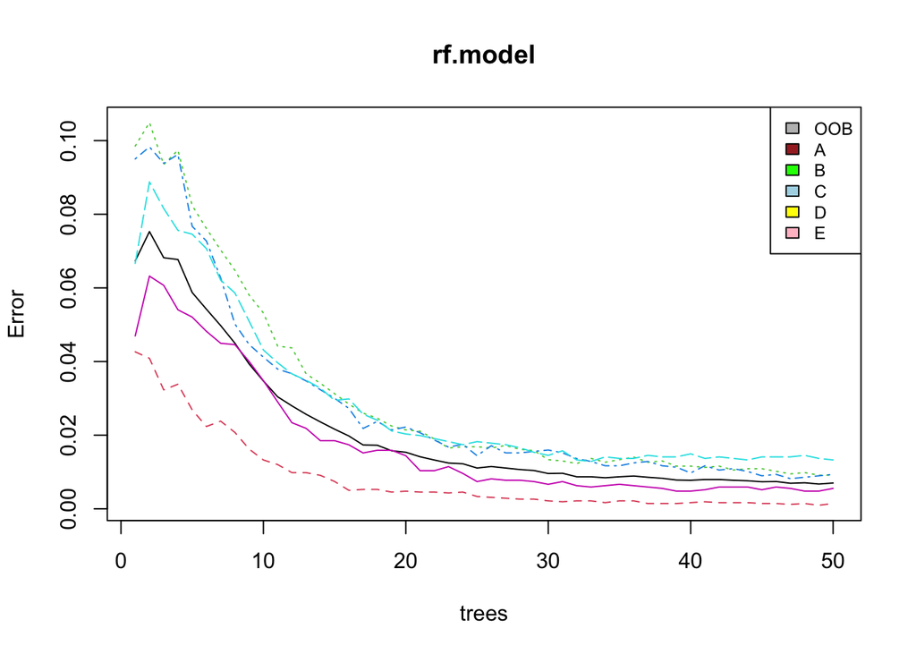

```r
plot(rf.model)
legend("topright", colnames(rf.model$err.rate),col=c("grey","brown","green","lightblue","yellow","pink"),cex=0.8,fill=c("grey","brown","green","lightblue","yellow","pink"))
```

### Prediction

```r
final.predict <- predict(rf.model, test, type = "class")

final.predict
```

```
##  1  2  3  4  5  6  7  8  9 10 11 12 13 14 15 16 17 18 19 20
##  B  A  B  A  A  E  D  B  A  A  B  C  B  A  E  E  A  B  B  B
## Levels: A B C D E
```

### Note

Random forest provides best accuracy of 0.9944 but can be overfitting. Second place is Generalized boosted model with accuracy of around 0.8144 and last one is prediction with tree with accuracy of 0.4957.